# align_clean

```python
import os

%load_ext rpy2.ipython
# import vamb
# %config IPCompleter.greedy=True
%config Completer.use_jedi = True
# %load_ext rpy2.ipython
```

```python
import pandas as pd
import numpy as np
```

```python
%ls ../
```

```
Ant_1/         align_log.tsv  my_interproscan/  see_some_results/  trees/
Bact_comm_4x/  ant_1/         ncbi/             server1_arc/       waypipe/
CheckM/        ant_1_tree/    notebooks/        somebases/
al_R/          metagenome/    plates/           temp/
```

В ноутбуке есть море отвратительно длинных выводов логов - я не буду с этим заморачиваться.

### Фильтр:

- то что не прошло IQ-tree
- хлоропласты и митохондрии
  - неидентифицировано
  - не проходит diamond
  - минор
  - длина отличается

```python
%cd ~/storage/trees/nal/
!ls -htl | head
```

```
/mnt/storage/trees/nal
total 130M
-rw-rw-r-- 1 gladkov2 gladkov2 499K Apr 26 09:17 iqtee_chi_al_d_2.tsv
-rw-r--r-- 1 gladkov2 gladkov2 1.2M Apr 23 14:39 taxa.txt
-rw-rw-r-- 1 gladkov2 gladkov2 3.3M Apr 23 14:39 otu.txt
-rw-rw-r-- 1 gladkov2 gladkov2 3.8M Apr 23 14:39 rep.fasta
-rw-rw-r-- 1 gladkov2 gladkov2 3.8M Apr 23 14:24 ref.fasta
-rw-r--r-- 1 gladkov2 gladkov2 1.6M Apr 23 13:00 ps_f.rds
-rw-rw-r-- 1 gladkov2 gladkov2 658K Apr 19 14:41 al_2_drna.log
-rw-rw-r-- 1 gladkov2 gladkov2 658K Apr 19 14:41 al_2_1.log
-rw-rw-r-- 1 gladkov2 gladkov2  14M Apr 19 14:41 al_2_drna.fasta
```

```python
%%R

a <- list.files()
```

выравнивание mafft

```python
!mafft --auto --thread 50 --inputorder "rep_seq.fasta" > "al_1.fasta"
```

[output not shown]

```python
!ls -htl
```

```
total 61M
-rw-rw-r-- 1 gladkov2 gladkov2  20M Apr  2 14:06 al_d_2.fasta
-rw-rw-r-- 1 gladkov2 gladkov2  37M Apr  2 11:57 al_1.fasta
-rw-r--r-- 1 gladkov2 gladkov2 796K Nov 20 12:01 ps.rds
-rw-r--r-- 1 gladkov2 gladkov2 4.1M Nov 19 15:42 rep_seq.fasta
-rw-r--r-- 1 gladkov2 gladkov2 5.5K Nov 19 15:42 track.tsv
```

выглядит не очень

```python
!head -n 50 al_1.fasta
```

```
>Seq1
------------------------------------------acgtaggtg---------
---------------------gc-------------aagcg-------------------
------------------------------------------------------------
-------------------ttgtc--cg------------------------------ga
at-------------------------------------tat----t-----gg-g-cg-
t-------------aa-ag-----------------------------------------
--------cg-cgc--gc-a-------------------------gg-cgg-tc-c-t-t
---------------------------t-------------------------------a
----------a---------------------------------------------gtc-
--------------t-g-a-t-------------------------------------gt
-------------------------------------g----------------------
---------------------------------------------aa-------------
-----------a-----------------------g--c-cc-------a-c-g------
-gc-tca------------------------acc-----------gtg------------
--gaggg---------tca-t---------------------------------------
-----------------------------t-g----g--------aaa------------
---------------------------------------------------------ct-
g-g------------g--gg-a--c------------t----t--ga-gtgc-a-gg---
-------a-ga-g---------------------------a-a-----------------
---------------------ga----------------------gtg-gaa--------
------ttc---ca------------------------------cgtg----------t-
a---------------------gcg----------gt------------gaaat------
-------gc-g-t-----------------------------------------------
-ag---------aga-------t-g-tg-----------------------g-agga---
----------------------a-cac------------------------c--------
-----a---------------g-t----------------------ggc-gaag-gcg--
--------------actc-t-tt---------------------------g---------
----gc-c----------------------------------------------------
----------------------------------------------------------t-
------------------------g-----------------------------------
------------------------------t-----------------------------
--------------------------------------a---------------------
---------------------------------------------a--------------
----------------c-----------------------t-g----------acgct--
------g-a-g-g-c-----------g-c-------------------------------
-------------------g-----------aaag-------------------------
---cgt---------------------------------------gggg-a---------
---------------------------------------gcaaacagg------------
-------------------------------------------
>Seq2
------------------------------------------acgtaggtg---------
---------------------gc-------------aagcg-------------------
------------------------------------------------------------
-------------------ttgtc--cg------------------------------ga
at-------------------------------------tat----t-----gg-g-cg-
t-------------aa-ag-----------------------------------------
--------cg-cgc--gc-a-------------------------gg-cgg-tc-c-t-t
---------------------------t-------------------------------a
----------a---------------------------------------------gtc-
```

Выравнивание в DECIPHER(более специализированный под 16S алгоритм)

```python
%%R

library(DECIPHER)
dna <- readDNAStringSet("rep_seq.fasta")
head(dna)
alignment <- AlignSeqs(DNAStringSet(dna), anchor=NA,verbose=FALSE, processors = 50)
writeXStringSet(alignment, file="al_d_2.fasta")
```

Выглядит чуть лучше, постараыемся это формализовать.

```python
!head -n 50 al_d_2.fasta
```

```
>Seq1
----------------ACGTAG----------GTG------GCAA------GCGTT-------GTCCGGAATT----A--
--TT---G-----G-----G----CG----------TAA---AGCG------CG----CG-----CA-------GGC---
---GG------TC----C------------T--T------------------------------------------T---
--AAG------------------------------------------------TC--T-----G-----A----T-----
---------------G------TGA--------------AAG----C----CCAC------GG--------C-----TCA
ACC--G--T-----G-G---------A----G---------GGT-----CA---T-------T-G---GAA--------A
CT-----G--G-G--G------G--A---C--T--------T----G---A--------G----TGC---A-----GGA-
----GAGAA------GA----GTG------G------------AA-----TT----CCA----------------C----
-GTG----T-----A---G-------CGG----T------GAAAT-------GCG---T-------AG------AGAT--
--GT-----------GGAGGA------ACA------CCA---G---T-------G------GC-----GAA-------GG
CG----AC-----TCT-----TTG------G---C--CT-----------------------------------------
---------------------------G-------------------------------------------TA-------
-------------------------------------------------------A----------CT------------
---------G-----AC--------G-----CTGA-----G-----G---------C--G---C------GAAAGCG---
-T---------------------------------------G------GGG-----AGC----A------AACAGG----
-------------------
>Seq2
----------------ACGTAG----------GTG------GCAA------GCGTT-------GTCCGGAATT----A--
--TT---G-----G-----G----CG----------TAA---AGCG------CG----CG-----CA-------GGC---
---GG------TC----C------------T--T------------------------------------------T---
--AAG------------------------------------------------TC--T-----G-----A----T-----
---------------G------TGA--------------AAG----C----CCAC------GG--------C-----TCA
ACC--G--T-----G-G---------A----G---------GGT-----CA---T-------T-G---GAA--------A
CT-----G--G-G--G------G--A---C--T--------T----G---A--------G----TAC---A-----GAA-
----GAGAA------GA----GTG------G------------AA-----TT----CCA----------------C----
-GTG----T-----A---G-------CGG----T------GAAAT-------GCG---T-------AG------AGAT--
--GT-----------GGAGGA------ACA------CCA---G---T-------G------GC-----GAA-------GG
CG----AC-----TCT-----TTG------G---T--CT-----------------------------------------
---------------------------G-------------------------------------------TA-------
-------------------------------------------------------A----------CT------------
---------G-----AC--------G-----CTGA-----G-----G---------C--G---C------GAAAGCG---
-T---------------------------------------G------GGG-----AGC----A------AACAGG----
-------------------
>Seq3
----------------ACAGAG----------GAT------GCAA------GCGTT-------ATCCGGAATG----A--
--TT---G-----G-----G----CG----------TAA---AGCG------TC----TG-----TA-------GGT---
---GG------CT----T------------T--T------------------------------------------C---
--AAG------------------------------------------------TC--C-----G-----C----C-----
---------------G------TCA--------------AAT----C----CCAG------GG--------C-----TCA
ACC--C--T-----G-G---------A----C---------AGG-----CG---G-------T-G---GAA--------A
CT-----A--C-C--A------A--G---C--T--------G----G---A--------G----TAC---G-----GTA-
----GGGGC------AG----AGG------G------------AA-----TT----TCC----------------G----
-GTG----G-----A---G-------CGG----T------GAAAT-------GCG---T-------TG------AGAT--
--CG-----------GAAAGA------ACA------CCA---A---C-------G------GC-----GAA-------AG
CA----CT-----CTG-----CTG------G---G--CC-----------------------------------------
---------------------------G-------------------------------------------AC-------
-------------------------------------------------------A----------CT------------
---------G-----AC--------A-----CTGA-----G-----A---------G--A---C------GAAAGCT---
-A---------------------------------------G------GGG-----AGC----A------AATGGG----
```

Воспользуемся для этого хи2 тестом из iqtree используя костыль.

```python
!timeout 5 iqtree -s al_1.fasta --prefix al_1_1
```

```python
!grep chi al_1_1.log
```

```
****  TOTAL      89.23%  3988 sequences failed composition chi2 test (p-value<5%; df=3)
```

```python
!rm iqtee_chi_al1_1.tsv
```

```python
!grep Seq al_1_1.log | sed 's/^ *//g' | sed 's/ \+ /\t/g' > iqtee_chi_al1_1.tsv
```

Сводная табличка по результатам xи2

```python
df = pd.read_csv("iqtee_chi_al1_1.tsv", delimiter='\t', header = None)
df
```

|  | 0 | 1 | 2 | 3 | 4 |
| --- | --- | --- | --- | --- | --- |
| 0 | 1 | Seq1 | 89.15% | passed | 16.22% |
| 1 | 2 | Seq2 | 89.15% | passed | 22.21% |
| 2 | 3 | Seq3 | 89.15% | passed | 22.49% |
| 3 | 4 | Seq4 | 92.81% | failed | 1.06% |
| 4 | 5 | Seq5 | 89.15% | passed | 25.56% |
| ... | ... | ... | ... | ... | ... |
| 16154 | 16155 | Seq16155 | 86.31% | passed | 37.86% |
| 16155 | 16156 | Seq16156 | 86.31% | passed | 27.84% |
| 16156 | 16157 | Seq16157 | 88.81% | failed | 3.59% |
| 16157 | 16158 | Seq16158 | 90.74% | passed | 6.29% |
| 16158 | 16159 | Seq16159 | 89.15% | passed | 14.00% |

16159 rows × 5 columns

```python
df.columns = ['somenumber', 'Id', 'Gap_Ambiguity', 'Composition', 'p-value']
# df_filt = df.query('Composition =="passed"')
df_filt = df[['Id', 'Composition']]
df_filt
```

|  | Id | Composition |
| --- | --- | --- |
| 0 | Seq1 | passed |
| 1 | Seq2 | passed |
| 2 | Seq3 | passed |
| 3 | Seq4 | failed |
| 4 | Seq5 | passed |
| ... | ... | ... |
| 16154 | Seq16155 | passed |
| 16155 | Seq16156 | passed |
| 16156 | Seq16157 | failed |
| 16157 | Seq16158 | passed |
| 16158 | Seq16159 | passed |

16159 rows × 2 columns

```python
# df.Id.to_csv(".txt", sep='\t', index=False, header=False)
```

Добавим таксономию.

```python
df_taxa = pd.read_csv("taxa.txt", delimiter='\t')
df_taxa = df_taxa.rename(columns={"Unnamed: 0":"Id"})
df_mix = df_taxa.merge(df_filt, on='Id')
df_mix['Res'] = np.where(((df_mix['Composition']=="failed") |
                            (df_mix['Order']=="Chloroplast") |
                            (df_mix['Family']=="Mitochondria")) ,False, True)
df_mix
```

|  | Id | Kingdom | Phylum | Class | Order | Family | Genus | Species | Composition | Res |
| --- | --- | --- | --- | --- | --- | --- | --- | --- | --- | --- |
| 0 | Seq1 | Bacteria | Firmicutes | Bacilli | Bacillales | Planococcaceae | NaN | longiquaesitum | passed | True |
| 1 | Seq2 | Bacteria | Firmicutes | Bacilli | Bacillales | NaN | NaN | NaN | passed | True |
| 2 | Seq3 | Bacteria | Cyanobacteria | Cyanobacteriia | Chloroplast | NaN | NaN | NaN | passed | False |
| 3 | Seq4 | Eukaryota | NaN | NaN | NaN | NaN | NaN | NaN | failed | False |
| 4 | Seq5 | Archaea | Crenarchaeota | Nitrososphaeria | Nitrososphaerales | Nitrososphaeraceae | NaN | NaN | passed | True |
| ... | ... | ... | ... | ... | ... | ... | ... | ... | ... | ... |
| 16154 | Seq16155 | Bacteria | Planctomycetota | Planctomycetes | Gemmatales | Gemmataceae | Telmatocola | NaN | passed | True |
| 16155 | Seq16156 | Bacteria | Chloroflexi | Ktedonobacteria | C0119 | NaN | NaN | NaN | passed | True |
| 16156 | Seq16157 | Eukaryota | NaN | NaN | NaN | NaN | NaN | NaN | failed | False |
| 16157 | Seq16158 | Eukaryota | NaN | NaN | NaN | NaN | NaN | NaN | passed | True |
| 16158 | Seq16159 | Bacteria | Actinobacteriota | Actinobacteria | Micromonosporales | Micromonosporaceae | NaN | NaN | passed | True |

16159 rows × 10 columns

Сколько не прошло хи2

```python
len(df_filt.query('Composition == "failed"'))
```

```
3988
```

```python
len(df_mix.query('Res == True'))
```

```
11909
```

```python
len(df_taxa)
```

```
16159
```

Сколько не определилось до филы.

```python
df_taxa['Phylum'].isna().sum()
# df_taxa.groupby(['Phylum']).Id.count()
```

```
1460
```

До домена

```python
# df_taxa.groupby(['Kingdom']).Id.count()
df_taxa['Kingdom'].isna().sum()
```

```
235
```

```python
%%R

list.files()
```

```
UsageError: Cell magic `%%R` not found.
```

```python
import seaborn as sns
import matplotlib.pyplot as plt
from Bio import SeqIO
import numpy as np
import pandas as pd
import math
```

Код для dencity plot судя по всему не в этом чанке.

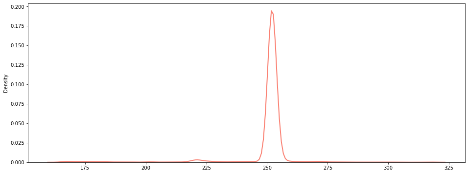

```python
path = "rep_seq.fasta"

sizes = [len(rec) for rec in SeqIO.parse(path, 'fasta')]
```

Добавляем представленность

```python
df_otus = pd.read_csv("otu_table.txt", delimiter='\t')
abundance = df_otus.sum(axis=1).tolist()
Id = df_filt.Id.tolist()
Kin = df_mix.Kingdom.tolist()
df_ill = pd.DataFrame({'len':sizes, 'abu':[math.log(x, 2) for x in abundance] ,'kin':Kin})
```

```python
df_ill.loc[(df_ill['abu'] > 10000) & (df_ill['len'] < 200)]
```

[output not shown]

```python
df_mix.loc[(df_mix['Id'] == 'Seq4') | (df_mix['Id'] == 'Seq8') ]
```

|  | Id | Kingdom | Phylum | Class | Order | Family | Genus | Species | Composition | Res |
| --- | --- | --- | --- | --- | --- | --- | --- | --- | --- | --- |
| 3 | Seq4 | Eukaryota | NaN | NaN | NaN | NaN | NaN | NaN | failed | False |
| 7 | Seq8 | Eukaryota | NaN | NaN | NaN | NaN | NaN | NaN | failed | False |

```python
df_ill.loc[(df_ill['abu'] > 10000) & (df_ill['len'] < 200)]
```

```python
df_mix['len'] = sizes
df_mix['abu'] = [math.log(x, 2) for x in abundance]
df_mix
```

|  | Id | Kingdom | Phylum | Class | Order | Family | Genus | Species | Composition | Res | len | abu |
| --- | --- | --- | --- | --- | --- | --- | --- | --- | --- | --- | --- | --- |
| 0 | Seq1 | Bacteria | Firmicutes | Bacilli | Bacillales | Planococcaceae | NaN | longiquaesitum | passed | True | 252 | 15.350732 |
| 1 | Seq2 | Bacteria | Firmicutes | Bacilli | Bacillales | NaN | NaN | NaN | passed | True | 252 | 14.813380 |
| 2 | Seq3 | Bacteria | Cyanobacteria | Cyanobacteriia | Chloroplast | NaN | NaN | NaN | passed | False | 252 | 14.800445 |
| 3 | Seq4 | Eukaryota | NaN | NaN | NaN | NaN | NaN | NaN | failed | False | 167 | 14.478959 |
| 4 | Seq5 | Archaea | Crenarchaeota | Nitrososphaeria | Nitrososphaerales | Nitrososphaeraceae | NaN | NaN | passed | True | 252 | 14.365092 |
| ... | ... | ... | ... | ... | ... | ... | ... | ... | ... | ... | ... | ... |
| 16154 | Seq16155 | Bacteria | Planctomycetota | Planctomycetes | Gemmatales | Gemmataceae | Telmatocola | NaN | passed | True | 318 | 0.000000 |
| 16155 | Seq16156 | Bacteria | Chloroflexi | Ktedonobacteria | C0119 | NaN | NaN | NaN | passed | True | 318 | 0.000000 |
| 16156 | Seq16157 | Eukaryota | NaN | NaN | NaN | NaN | NaN | NaN | failed | False | 260 | 0.000000 |
| 16157 | Seq16158 | Eukaryota | NaN | NaN | NaN | NaN | NaN | NaN | passed | True | 215 | 0.000000 |
| 16158 | Seq16159 | Bacteria | Actinobacteriota | Actinobacteria | Micromonosporales | Micromonosporaceae | NaN | NaN | passed | True | 252 | 0.000000 |

16159 rows × 12 columns

Плохо выравнивается то, что не подходит по длине.

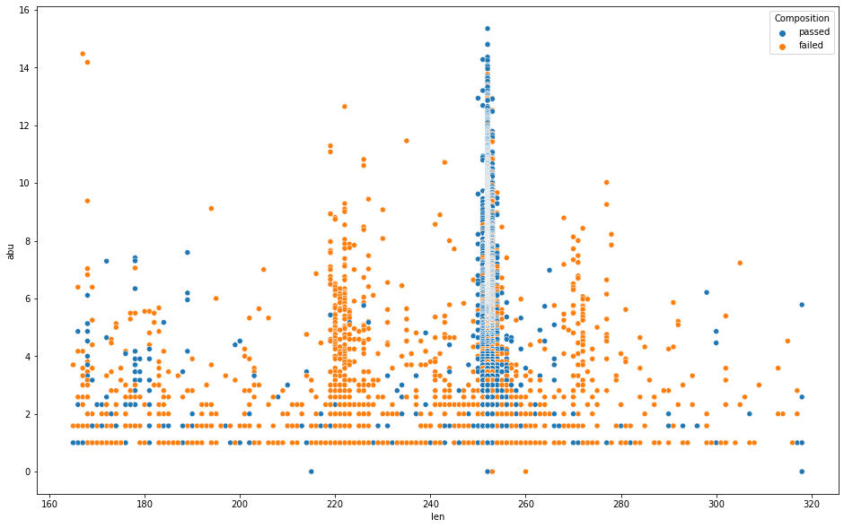

```python
plt.figure(figsize=(16, 10))
sns.scatterplot(
    data=df_mix,
    x='len',
    y='abu',
    hue='Composition'
)
```

Это эукариоты.

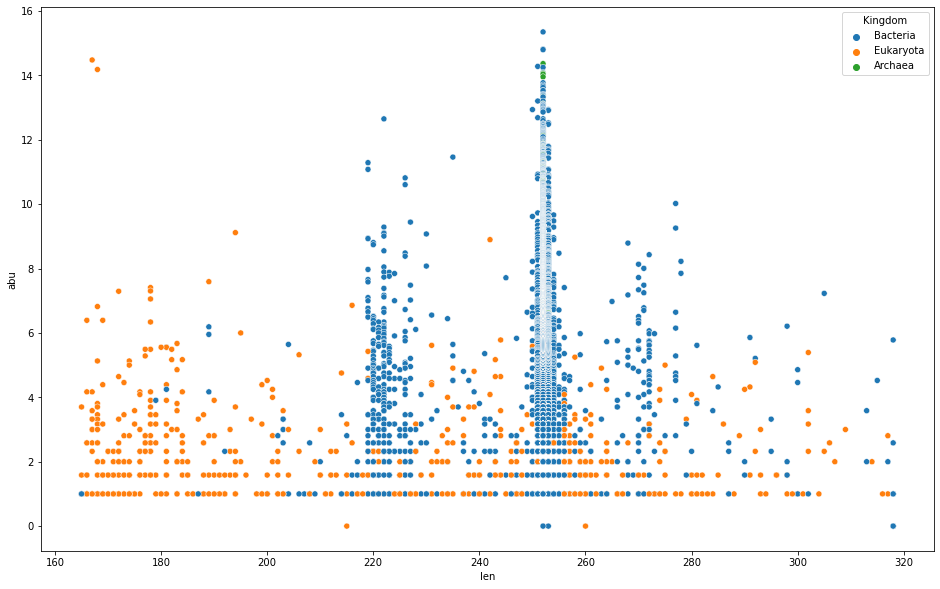

```python
plt.figure(figsize=(16, 10))
sns.scatterplot(
    data=df_mix,
    x='len',
    y='abu',
    hue='Kingdom'
)
```

Это органеллы.

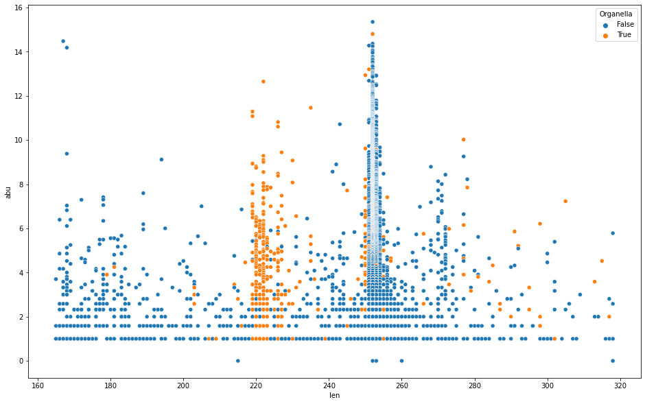

```python
df_mix['Organella'] = np.where(((df_mix['Order']=="Chloroplast") |
                            (df_mix['Family']=="Mitochondria")) ,True, False)
plt.figure(figsize=(16, 10))
sns.scatterplot(
    data=df_mix,
    x='len',
    y='abu',
    hue='Organella'
)
```

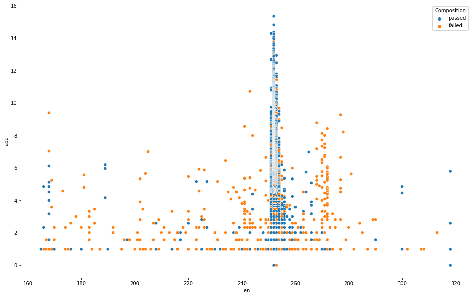

```python
df_right = df_mix.query('Organella==False & Kingdom!="Eukaryota"')

plt.figure(figsize=(16, 10))
sns.scatterplot(
    data=df_right,
    x='len',
    y='abu',
    hue='Composition'
)
```

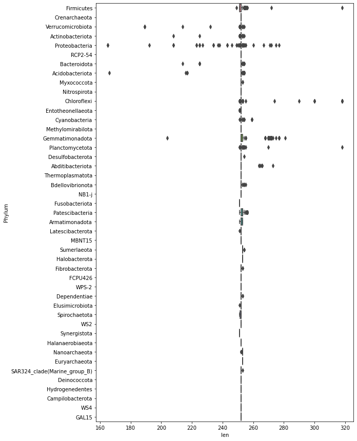

```python
plt.figure(figsize=(9, 15))
sns.boxplot(data=df_right, orient="h", y='Phylum', x='len')`
```

Это бактерии филы Gemmatimonadota.

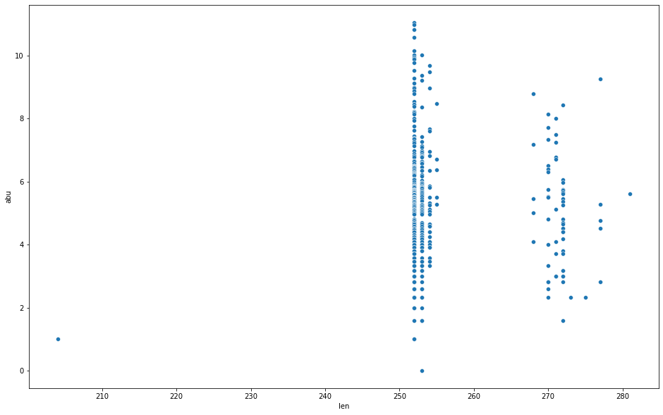

```python
plt.figure(figsize=(16, 10))
sns.scatterplot(
    data=df_right.query('Phylum == "Gemmatimonadota"'),
    x='len',
    y='abu'
)
```

Убираем органеллы и эукариот. \ Заново выравниваем

```python
!ls
```

```
al_1.fasta    iqtee_chi_al1_1.tsv  ps.rds	  test
al_1_1.log    otu_table.biom	   rep_seq.fasta  track.tsv
al_d_2.fasta  otu_table.txt	   taxa.txt
```

Фильтрация в R(у Зверева реально лучше реализация)

```python
%%R

library(phyloseq)
library(Biostrings)

ps <- read_rds("ps.rds")
ps <- merge_phyloseq(ps, refseq(readDNAStringSet("rep_seq.fasta")))

pop_taxa <- function(physeq, badTaxa){
  allTaxa = taxa_names(physeq)
  myTaxa <- allTaxa[!(allTaxa %in% badTaxa)]
  return(prune_taxa(myTaxa, physeq))
}

delete_mit_chl_eu <- function(ps){
  badTaxa <- taxa_names(subset_taxa(ps, Order=="Chloroplast"))
  ps <- pop_taxa(ps, badTaxa)
  badTaxa <- taxa_names(subset_taxa(ps, Family=="Mitochondria"))
  ps <- pop_taxa(ps, badTaxa)
  badTaxa <- taxa_names(subset_taxa(ps, Kingdom == "Eukaryota"))
  ps <- pop_taxa(ps, badTaxa)
  badTaxa <- taxa_names(subset_taxa(ps, is.na(Phylum)))
  ps <- pop_taxa(ps, badTaxa)
  return(ps)
}

saveRDS(ps.f, file = "ps_f.rds")
ps.f <- delete_mit_chl_eu(ps)
writeXStringSet(ps.f@refseq, file="ref_filt.fasta")
```

Выравнивание в mafft

```python
!mafft --auto --thread 50 --inputorder "ref_filt.fasta" > "al_2.fasta"
```

[output not shown]

```python
!timeout 5 iqtree -s al_2.fasta --prefix al_2_1
```

```
IQ-TREE multicore version 2.1.2 COVID-edition for Linux 64-bit built Mar 30 2021
Developed by Bui Quang Minh, James Barbetti, Nguyen Lam Tung,
Olga Chernomor, Heiko Schmidt, Dominik Schrempf, Michael Woodhams.

Host:    8753872069ef (AVX512, FMA3, 2708 GB RAM)
Command: iqtree -s al_2.fasta --prefix al_2_1
Seed:    647323 (Using SPRNG - Scalable Parallel Random Number Generator)
Time:    Mon Apr 19 13:50:24 2021
Kernel:  AVX+FMA - 1 threads (208 CPU cores detected)

HINT: Use -nt option to specify number of threads because your CPU has 208 cores!
HINT: -nt AUTO will automatically determine the best number of threads to use.

Reading alignment file al_2.fasta ... Fasta format detected
Alignment most likely contains DNA/RNA sequences
Alignment has 14828 sequences with 1278 columns, 1137 distinct patterns
801 parsimony-informative, 221 singleton sites, 256 constant sites
          Gap/Ambiguity  Composition  p-value
   1  Seq16007   84.74%    failed      0.08%
   2  Seq13966   80.67%    failed      0.00%
   3  Seq15747   81.77%    failed      0.00%
   4  Seq15400   85.92%    failed      0.24%
   5  Seq10913   78.79%    failed      0.01%
   6  Seq14445   83.33%    failed      0.03%
   7  Seq16096   81.53%    failed      0.00%
   8  Seq15482   86.38%    failed      0.01%
   9  Seq16057   86.31%    failed      0.02%
  10  Seq16145   86.78%    failed      0.22%
  11  Seq15178   84.66%    failed      0.02%
  12  Seq15307   84.51%    failed      0.00%
  13  Seq16111   85.37%    failed      0.03%
  14  Seq15593   80.13%    passed     83.57%
  15  Seq15681   80.20%    passed     44.51%
  16  Seq10274   80.20%    passed     51.77%
  17  Seq13971   86.38%    failed      1.02%
  18  Seq13135   80.20%    passed     69.90%
  19  Seq13143   80.20%    passed     71.67%
  И т.д.

14825  Seq2805    80.28%    passed     73.42%
14826  Seq4034    80.28%    passed     64.30%
14827  Seq7258    80.28%    passed     71.48%
14828  Seq15967   80.28%    passed     54.77%
WARNING: 14828 sequences contain more than 50% gaps/ambiguity
****  TOTAL      80.29%  1350 sequences failed composition chi2 test (p-value<5%; df=3)
```

```python
!timeout 5 iqtree -s al_2_drna.fasta --prefix al_2_drna
```

```
IQ-TREE multicore version 2.1.2 COVID-edition for Linux 64-bit built Mar 30 2021
Developed by Bui Quang Minh, James Barbetti, Nguyen Lam Tung,
Olga Chernomor, Heiko Schmidt, Dominik Schrempf, Michael Woodhams.

Host:    8753872069ef (AVX512, FMA3, 2708 GB RAM)
Command: iqtree -s al_2_drna.fasta --prefix al_2_drna
Seed:    574271 (Using SPRNG - Scalable Parallel Random Number Generator)
Time:    Mon Apr 19 14:41:13 2021
Kernel:  AVX+FMA - 1 threads (208 CPU cores detected)

HINT: Use -nt option to specify number of threads because your CPU has 208 cores!
HINT: -nt AUTO will automatically determine the best number of threads to use.

Reading alignment file al_2_drna.fasta ... Fasta format detected
Alignment most likely contains DNA/RNA sequences
Alignment has 14828 sequences with 913 columns, 777 distinct patterns
490 parsimony-informative, 139 singleton sites, 284 constant sites
          Gap/Ambiguity  Composition  p-value
   1  Seq16007   78.64%    failed      0.03%
...
   14827  Seq7258    72.40%    passed     84.13%
14828  Seq15967   72.40%    passed     74.84%
WARNING: 14828 sequences contain more than 50% gaps/ambiguity
****  TOTAL      72.41%  1241 sequences failed composition chi2 test (p-value<5%; df=3)
```

```python
!grep chi al_2_1.log
```

```
****  TOTAL      80.29%  1350 sequences failed composition chi2 test (p-value<5%; df=3)
```

```python
!grep chi al_1_1.log
```

```
****  TOTAL      89.23%  3988 sequences failed composition chi2 test (p-value<5%; df=3)
```

```python
!grep chi al_2_d.log
```

```
****  TOTAL      71.02%  1259 sequences failed composition chi2 test (p-value<5%; df=3)
```

```python
!grep chi al_2_drna.log
```

```
****  TOTAL      72.41%  1241 sequences failed composition chi2 test (p-value<5%; df=3)
```

Выравнивание в DECIPHER в двух режимах(c учетом вторичной структуры RNA)

```python
%%R

library(DECIPHER)
dna <- readDNAStringSet("ref_filt.fasta")
head(dna)
alignment <- AlignSeqs(RNAStringSet(dna), anchor=NA,verbose=FALSE, processors = 50)
alignment <- DNAStringSet(alignment)
writeXStringSet(alignment, file="al_2_drna.fasta")
```

```python
!timeout 5 iqtree -s al_2_d.fasta --prefix al_2_d
```

```
IQ-TREE multicore version 2.1.2 COVID-edition for Linux 64-bit built Mar 30 2021
Developed by Bui Quang Minh, James Barbetti, Nguyen Lam Tung,
Olga Chernomor, Heiko Schmidt, Dominik Schrempf, Michael Woodhams.

Host:    8753872069ef (AVX512, FMA3, 2708 GB RAM)
Command: iqtree -s al_2_d.fasta --prefix al_2_d
Seed:    36355 (Using SPRNG - Scalable Parallel Random Number Generator)
Time:    Mon Apr 19 14:10:39 2021
Kernel:  AVX+FMA - 1 threads (208 CPU cores detected)

HINT: Use -nt option to specify number of threads because your CPU has 208 cores!
HINT: -nt AUTO will automatically determine the best number of threads to use.

Reading alignment file al_2_d.fasta ... Fasta format detected
Alignment most likely contains DNA/RNA sequences
Alignment has 14828 sequences with 869 columns, 775 distinct patterns
525 parsimony-informative, 137 singleton sites, 207 constant sites
          Gap/Ambiguity  Composition  p-value
   1  Seq16007   77.56%    failed      0.02%
  ...
14826  Seq4034    71.00%    passed     80.76%
14827  Seq7258    71.00%    passed     85.11%
14828  Seq15967   71.00%    passed     76.78%
WARNING: 14828 sequences contain more than 50% gaps/ambiguity
****  TOTAL      71.02%  1259 sequences failed composition chi2 test (p-value<5%; df=3)
```

```python
%%R

library(DECIPHER)
dna <- readDNAStringSet("ref_filt.fasta")
head(dna)
alignment <- AlignSeqs(DNAStringSet(dna), anchor=NA,verbose=FALSE, processors = 50)
writeXStringSet(alignment, file="al_2_d.fasta")
```

Статистика сторонней тулой

```python
!esl-alistat al_2_drna.fasta
```

```
Alignment number:    1
Format:              aligned FASTA
Number of sequences: 14828
Alignment length:    913
Total # residues:    3734491
Smallest:            165
Largest:             318
Average length:      251.9
Average identity:    72%
//
```

```python
!esl-alistat al_1.fasta
```

```
Alignment number:    1
Format:              aligned FASTA
Number of sequences: 16159
Alignment length:    2323
Total # residues:    4041636
Smallest:            165
Largest:             318
Average length:      250.1
Average identity:    66%
//
```

```python
!esl-alistat al_d_2.fasta
```

```
Alignment number:    1
Format:              aligned FASTA
Number of sequences: 16159
Alignment length:    1219
Total # residues:    4041636
Smallest:            165
Largest:             318
Average length:      250.1
Average identity:    68%
//
```

```python
!esl-alistat al_2.fasta
```

```
Alignment number:    1
Format:              aligned FASTA
Number of sequences: 14828
Alignment length:    1278
Total # residues:    3734491
Smallest:            165
Largest:             318
Average length:      251.9
Average identity:    71%
//
```

```python
!esl-alistat al_2_d.fasta
```

```
Alignment number:    1
Format:              aligned FASTA
Number of sequences: 14828
Alignment length:    869
Total # residues:    3734491
Smallest:            165
Largest:             318
Average length:      251.9
Average identity:    72%
//
```

По итогу я решил использовать выравнивание от DECIPHER без режима для РНК.

```python
%%R

library(phyloseq)
library(tidyverse)
library(DECIPHER)



ps.f <- read_rds("ps_f.rds")
writeXStringSet(ps.f@refseq, file="rep.fasta")
write.table(t(ps.f@otu_table@.Data), file = "otu.txt", sep= "\t", col.names = NA, quote=FALSE)
write.table(ps.f@tax_table@.Data, file = "taxa.txt", sep= "\t", col.names = NA, quote=FALSE)
```

```python
!grep Seq al_2_d.log | sed 's/^ *//g' | sed 's/ \+ /\t/g' > iqtee_chi_al_d_2.tsv

df = pd.read_csv("iqtee_chi_al_d_2.tsv", delimiter='\t', header = None)
df.columns = ['somenumber', 'Id', 'Gap_Ambiguity', 'Composition', 'p-value']
df_filt = df[['Id', 'Composition']]

df_otus = pd.read_csv("otu.txt", delimiter='\t')
abundance = df_otus.sum(axis=1).tolist()

df_taxa = pd.read_csv("taxa.txt", delimiter='\t')
df_taxa = df_taxa.rename(columns={"Unnamed: 0":"Id"})

path = "rep.fasta"
sizes = [len(rec) for rec in SeqIO.parse(path, 'fasta')]

df_mix = df_taxa.merge(df_filt, on='Id')
df_mix['len'] = sizes
df_mix['abu'] = [math.log(x, 2) for x in abundance]

df_mix
```

|  | Id | Kingdom | Phylum | Class | Order | Family | Genus | Species | Composition | len | abu |
| --- | --- | --- | --- | --- | --- | --- | --- | --- | --- | --- | --- |
| 0 | Seq16007 | NaN | NaN | NaN | NaN | NaN | NaN | NaN | failed | 195 | 1.000000 |
| 1 | Seq13966 | NaN | NaN | NaN | NaN | NaN | NaN | NaN | failed | 247 | 2.321928 |
| 2 | Seq15747 | NaN | NaN | NaN | NaN | NaN | NaN | NaN | failed | 233 | 1.000000 |
| 3 | Seq15400 | NaN | NaN | NaN | NaN | NaN | NaN | NaN | failed | 180 | 1.000000 |
| 4 | Seq10913 | NaN | NaN | NaN | NaN | NaN | NaN | NaN | failed | 271 | 3.321928 |
| ... | ... | ... | ... | ... | ... | ... | ... | ... | ... | ... | ... |
| 14823 | Seq926 | Bacteria | Proteobacteria | Gammaproteobacteria | Aeromonadales | Aeromonadaceae | Aeromonas | NaN | passed | 252 | 8.839204 |
| 14824 | Seq2805 | Bacteria | Proteobacteria | Gammaproteobacteria | Alteromonadales | Shewanellaceae | Shewanella | NaN | passed | 252 | 6.714246 |
| 14825 | Seq4034 | Bacteria | Proteobacteria | Gammaproteobacteria | Vibrionales | Vibrionaceae | Photobacterium | NaN | passed | 252 | 5.954196 |
| 14826 | Seq7258 | Bacteria | Proteobacteria | Gammaproteobacteria | Vibrionales | Vibrionaceae | Vibrio | NaN | passed | 252 | 4.584963 |
| 14827 | Seq15967 | Bacteria | NaN | NaN | NaN | NaN | NaN | NaN | passed | 252 | 1.000000 |

14828 rows × 11 columns

```python
df_mix
```

[output not shown]

Стало лучше - да.

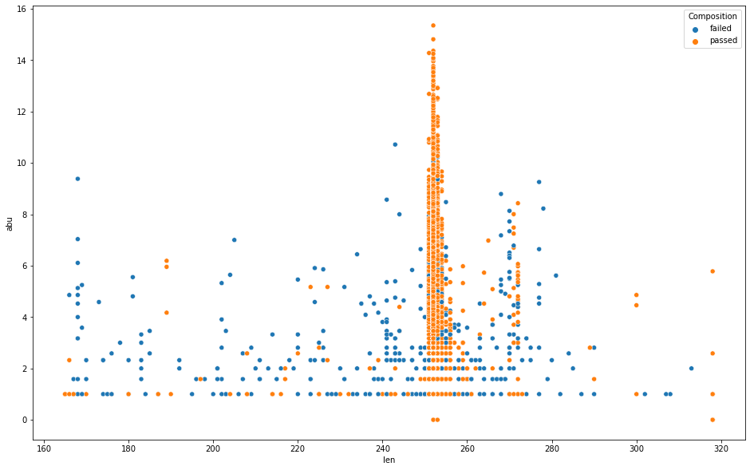

```python
plt.figure(figsize=(16, 10))
sns.scatterplot(
    data=df_mix,
    x='len',
    y='abu',
    hue='Composition'
)
```

Различия в длине ридов таксонспецифичны.

```python
pd.set_option('display.max_rows', None)
df_mix.query('(Composition == "failed") & (Phylum)').sort_values('len', ascending=False).groupby("Order").size().sort_values(ascending=False)
```

```
Order
Gemmatimonadales                       132
Chloroflexales                          74
Chitinophagales                         73
Kallotenuales                           69
Thermomicrobiales                       65
Gemmatales                              62
Flavobacteriales                        40
Isosphaerales                           37
Sphingobacteriales                      28
Cytophagales                            17
Bacteroidales                           14
Ktedonobacterales                       12
Entomoplasmatales                       11
Planctomycetales                         8
Tepidisphaerales                         6
Peptostreptococcales-Tissierellales      5
Rokubacteriales                          5
SBR1031                                  5
Saccharimonadales                        5
Acetobacterales                          5
Longimicrobiales                         4
Rhodospirillales                         2
Rickettsiales                            2
Coriobacteriales                         2
Campylobacterales                        2
Bacteroidetes_VC2.1_Bac22                2
Nitrospirales                            1
Opitutales                               1
11-24                                    1
Mycoplasmatales                          1
Holosporales                             1
Absconditabacteriales_(SR1)              1
Elev-1554                                1
DS-100                                   1
Cyanobacteriales                         1
Candidatus_Yanofskybacteria              1
Candidatus_Woesebacteria                 1
Candidatus_Daviesbacteria                1
Ardenticatenales                         1
Actinomycetales                          1
Tistrellales                             1
dtype: int64
```

```python
df_mix.query('Family == "Isosphaeraceae"').groupby("Composition").size()
```

```
Composition
failed    37
passed    33
dtype: int64
```

```python
df_mix.groupby("Kingdom").size().sort_values(ascending=False)
```

```
Kingdom
Bacteria    14459
Archaea       134
dtype: int64
```

Это другая работа, наверное. Я использовал что-топодобное чтобы мне логи кидались в телегу из iqtree

```python
%%bash

tail -n 10 ~/storage/trees/Vasya/same_leng_aln.fa.log | telegram-send --stdin
# telegram-send $text
FILE=/etc/resolv.confx-special/nautilus-clipboard
copy
file:///home/crabron/server2/trees/BI4/its_al_maf.fasta.treefile
if test -f "$FILE"; then
    echo "$FILE exists."
fi
```

```python
%%R

library(DECIPHER)
dna <- readDNAStringSet("ref.fasta")
head(dna)
alignment <- AlignSeqs(DNAStringSet(dna), anchor=NA,verbose=FALSE, processors = 50)
writeXStringSet(alignment, file="al_3_d.fasta")
```

```python
%%R

library(DECIPHER)
dna <- readDNAStringSet("ref.fasta")
head(dna)
alignment <- AlignSeqs(RNAStringSet(dna), anchor=NA,verbose=FALSE, processors = 50)
writeXStringSet(alignment, file="al_3_drna.fasta")
```

```python
!mafft --auto --thread 50 --inputorder "ref.fasta" > "al_3.fasta"
```

[output not shown]

```python
%ll -hlt | head -n 4
```

```
total 176M
-rw-rw-r-- 1 gladkov2  19M Apr 26 14:45 al_3.fasta
-rw-rw-r-- 1 gladkov2  14M Apr 26 14:44 al_3_drna.fasta
-rw-rw-r-- 1 gladkov2  13M Apr 26 14:30 al_3_d.fasta
```

```python
!esl-alistat al_3_d.fasta
```

```
Alignment number:    1
Format:              aligned FASTA
Number of sequences: 14828
Alignment length:    877
Total # residues:    3734491
Smallest:            165
Largest:             318
Average length:      251.9
Average identity:    72%
//
```

```python
!esl-alistat al_3_drna.fasta
```

```
Alignment number:    1
Format:              aligned FASTA
Number of sequences: 14828
Alignment length:    915
Total # residues:    3734491
Smallest:            165
Largest:             318
Average length:      251.9
Average identity:    72%
//
```

```python
!esl-alistat al_3.fasta
```

```
Alignment number:    1
Format:              aligned FASTA
Number of sequences: 14828
Alignment length:    1278
Total # residues:    3734491
Smallest:            165
Largest:             318
Average length:      251.9
Average identity:    71%
//
```

```python
!timeout 5 iqtree -s al_3_d.fasta --prefix al_3_d  --quiet
!grep chi al_3_d.log
```

```
****  TOTAL      71.28%  1254 sequences failed composition chi2 test (p-value<5%; df=3)
```

```python
!timeout 5 iqtree -s al_3_drna.fasta --prefix al_3_drna --quiet
!grep chi al_3_drna.log
```

```
****  TOTAL      72.47%  1241 sequences failed composition chi2 test (p-value<5%; df=3)
```

```python
!timeout 5 iqtree -s  al_3.fasta --prefix al_3 --quiet
!grep chi al_3.log
```

```
****  TOTAL      80.29%  1350 sequences failed composition chi2 test (p-value<5%; df=3)
```

```python
!grep Seq al_3_d.log | sed 's/^ *//g' | sed 's/ \+ /\t/g' > iqtee_chi_al_d_3.tsv

df = pd.read_csv("iqtee_chi_al_d_2.tsv", delimiter='\t', header = None)
df.columns = ['somenumber', 'Id', 'Gap_Ambiguity', 'Composition', 'p-value']
df_filt = df[['Id', 'Composition']]

df_otus = pd.read_csv("otu.txt", delimiter='\t')
abundance = df_otus.sum(axis=1).tolist()

df_taxa = pd.read_csv("taxa.txt", delimiter='\t')
df_taxa = df_taxa.rename(columns={"Unnamed: 0":"Id"})

path = "rep.fasta"
sizes = [len(rec) for rec in SeqIO.parse(path, 'fasta')]

df_mix = df_taxa.merge(df_filt, on='Id')
df_mix['len'] = sizes
df_mix['abu'] = [math.log(x, 2) for x in abundance]

df_mix
```

[output not shown]

Все то же самое - но я убрал всё что не определилось до филы. \ Стало очень хорошо. Там был выдимо кусок работы в Rstudia, когда я бластил отдельные представленные неидентифицмированные филотипы(ASV), чтобы убедиться что это действительно мусор

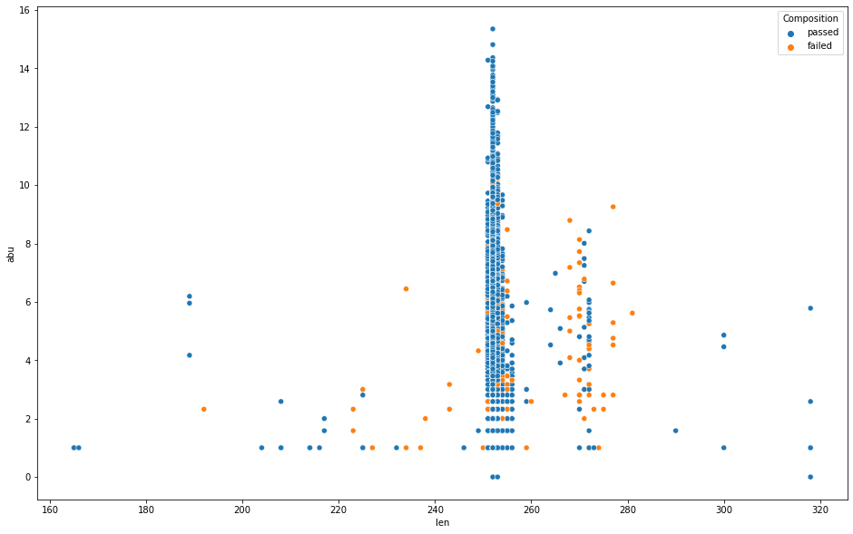

```python
plt.figure(figsize=(16, 10))
sns.scatterplot(
    data=df_mix,
    x='len',
    y='abu',
    hue='Composition'
)
```

```python
df_mix.query('Composition=="failed"').count()
```

```
Id             838
Kingdom        838
Phylum         838
Class          770
Order          702
Family         668
Genus          286
Species         11
Composition    838
len            838
abu            838
dtype: int64
```

Все, меня это устроило и я запустил на неделю iqtree. \ Потом перестроил уже без всего этого в SEPP, т.к. оказалось, что всё равно дерево вышло поганым.

```python
!iqtree -s al_3_d.fasta -nt 30 -B 1000
```

```
IQ-TREE multicore version 2.1.2 COVID-edition for Linux 64-bit built Mar 30 2021
Developed by Bui Quang Minh, James Barbetti, Nguyen Lam Tung,
Olga Chernomor, Heiko Schmidt, Dominik Schrempf, Michael Woodhams.

Host:    8753872069ef (AVX512, FMA3, 2708 GB RAM)
Command: iqtree -s al_3_d.fasta -nt 30 -B 1000
Seed:    24462 (Using SPRNG - Scalable Parallel Random Number Generator)
Time:    Mon Apr 26 14:59:58 2021
Kernel:  AVX+FMA - 30 threads (208 CPU cores detected)

Reading alignment file al_3_d.fasta ... Fasta format detected
Alignment most likely contains DNA/RNA sequences
Alignment has 14828 sequences with 877 columns, 779 distinct patterns
528 parsimony-informative, 135 singleton sites, 214 constant sites
          Gap/Ambiguity  Composition  p-value
   1  Seq16007   77.77%    failed      0.03%
   2  Seq13966   71.84%    failed      0.00%
...
14825  Seq2805    71.27%    passed     90.40%
14826  Seq4034    71.27%    passed     80.53%
14827  Seq7258    71.27%    passed     84.94%
14828  Seq15967   71.27%    passed     76.44%
WARNING: 14828 sequences contain more than 50% gaps/ambiguity
****  TOTAL      71.28%  1254 sequences failed composition chi2 test (p-value<5%; df=3)

NOTE: Restoring information from model checkpoint file al_3_d.fasta.model.gz

CHECKPOINT: Initial tree restored
WARNING: Number of threads seems too high for short alignments. Use -T AUTO to determine best number of threads.
Perform fast likelihood tree search using GTR+I+G model...
Estimate model parameters (epsilon = 5.000)
Perform nearest neighbor interchange...
Estimate model parameters (epsilon = 1.000)
1. Initial log-likelihood: -558634.099
2. Current log-likelihood: -558622.053
3. Current log-likelihood: -558620.097
Optimal log-likelihood: -558619.863
Rate parameters:  A-C: 0.86330  A-G: 2.40308  A-T: 1.49810  C-G: 0.63581  C-T: 4.45988  G-T: 1.00000
Base frequencies:  A: 0.253  C: 0.200  G: 0.351  T: 0.196
Proportion of invariable sites: 0.000
Gamma shape alpha: 0.643
Parameters optimization took 3 rounds (171.491 sec)
Time for fast ML tree search: 1182.339 seconds

NOTE: ModelFinder requires 3772 MB RAM!
ModelFinder will test up to 286 DNA models (sample size: 877) ...
 No. Model         -LnL         df  AIC          AICc         BIC
WARNING: Number of threads seems too high for short alignments. Use -T AUTO to determine best number of threads.
  1  GTR+F         629676.290   29661 1318674.580  1760927838.580 1460350.554
WARNING: Number of threads seems too high for short alignments. Use -T AUTO to determine best number of threads.
  2  GTR+F+I       629675.889   29662 1318675.777  1761046487.777 1460356.528
WARNING: Number of threads seems too high for short alignments. Use -T AUTO to determine best number of threads.
  3  GTR+F+G4      558619.434   29662 1176562.868  1760904374.868 1318243.619
WARNING: Number of threads seems too high for short alignments. Use -T AUTO to determine best number of threads.
  4  GTR+F+I+G4    558619.419   29663 1176564.837  1761023028.837 1318250.364
WARNING: Number of threads seems too high for short alignments. Use -T AUTO to determine best number of threads.
  5  GTR+F+R2      574770.565   29663 1208867.131  1761055331.131 1350552.657
WARNING: Number of threads seems too high for short alignments. Use -T AUTO to determine best number of threads.
  6  GTR+F+R3      562988.577   29665 1185307.153  1761269087.153 1327002.233
WARNING: Number of threads seems too high for short alignments. Use -T AUTO to determine best number of threads.
^C
```